# Census Data in R: Introduction to tidycensus

Carmen Rodriguez

2025-10-28

## TL;DR: Census and American Community Survey Data via `tidycensus`

- Obtain a Census API key: https://api.census.gov/data/key_signup.html
- Core functions in `tidycensus` include:
  - `get_decennial()`, which requests data from the US Decennial Census APIs for 2000, 2010, and 2020.
  - `get_acs()`, which requests data from the 1-year and 5-year American Community Survey samples. Data are available from the 1-year ACS back to 2005 and the 5-year ACS back to 2005-2009.
- Retrieve `tidyverse`-ready data format (or traditional wide format if requested).
- Explore and visualize data with `ggplot2`.
- See the book [Analyzing US Census Data: Methods, Maps, and Models in R](https://walker-data.com/census-r/index.html) by Kyle Walker.
- **Ethics & integrity**: Avoid misleading color scales or changing breakpoints over time. Prefer consistent bins, clear titles, and notes on data sources.

`tidycensus` is designed to help R users get Census data that is prepared for exploration within the `tidyverse`, and optionally spatially as it automatically downloads and merges Census geometries to data for mapping.

We will see several of the options available with this package, but you can read more about the `tidycensus` package [here](https://walker-data.com/tidycensus/) and see more examples [here](https://walker-data.com/census-r/).

## Census hierarchy and Data Downloads

Aggregate data from the decennial U.S Census, American Community Survey (ACS), and other Census surveys are released for various geographic units called *enumeration units*. These include legal entities like states and counties, as well as statistical areas used for standardized reporting.

This hierarchy is summarized in the graphic below (from https://www.census.gov/programs-surveys/geography/guidance/hierarchy.html).

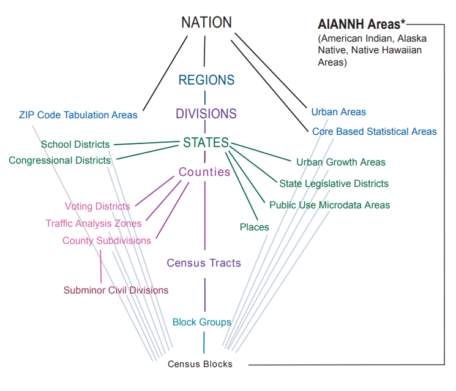

Source: US Census Bureau

U.S. Census data are available from a variety of sources. For years, researchers would visit the **US Census Bureau’s American FactFinder** site to download Census data for custom geographies. American FactFinder was decommissioned in 2020, giving way to a new data download interface, (https://data.census.gov).

[figure not shown]

## Census Bureau’s data API

- **APIs** let users and software access data directly from large databases like the U.S. Census.
- They provide **programmatic access** to data- meaning you can retrieve information automatically without manually downloading files.
- **Software packages** (like `tidycensus` in R) simplify API use, so you can get data with just one line of code.
- APIs enable **automation, reproducibility, and scalability** which as you guys are learning in this class are key skills for data analysis and research.
- Access typically requires a **free API key**, which identifies you as a user and manages access limits.

[Get your Census API key](https://api.census.gov/data/key_signup.html)

## Setup

```r
#install.packages("tidycensus")
library(tidycensus)
library(tidyverse)


#Set your Census API key with the census_api_key() function (only need to do this once!)

#census_api_key("YOUR_KEY_HERE", install = TRUE) #install=TRUE installs the key for use in future R sessions

#readRenviron("~/.Renviron") #run this to use  API key

#Check API key
#Sys.getenv("CENSUS_API_KEY")
```

## Retrieving data

You can retrieve data using functions `get_decennial()`, which requests data from the US Decennial Census APIs for 2000, 2010, and 2020. And `get_acs()`, which requests data from the 1-year and 5-year American Community Survey samples. Data are available from the 1-year ACS back to 2005 and the 5-year ACS back to 2005-2009.

The structure of these functions is very similar:

```
get_decennial(geography, variables, year, state = NULL, county = NULL, geometry = FALSE, ...)`


get_acs(geography, variables, year, survey = "acs5", state = NULL, county = NULL, geometry = FALSE, summary_var= ...)`
```

They retrieve data from the U.S. Census Bureau’s APIs and return a **tidy tibble** with columns like:

- **GEOID** – unique geographic identifier
- **NAME** – name of the area (e.g., “Cook County, Illinois”)
- **variable** – variable ID (e.g., “B01003_001”)
- **estimate** – estimated value for that variable
- **moe** – margin of error (for ACS only)
- **geometry (optional)** – spatial boundaries for mapping

| Argument | Description |
| --- | --- |
| **`geography`** | The geographic level of data (e.g., `"state"`, `"county"`, `"tract"`, `"block group"`). |
| **`variables`** | One or more variable IDs to pull (e.g., `"B19013_001"` for median income). You can also use `load_variables()` to look up variable names. |
| **`year`** | The year of the data. For example, `year = 2022`. |
| **`state`, `county`** | Optional filters to limit the data to a specific state or county. |
| **`geometry`** | If `TRUE`, returns spatial data (simple features) for mapping. If `FALSE`, returns only a table. |
| **`survey`** *(ACS only)* | Choose between `"acs1"` (1-year) or `"acs5"` (5-year) data. Most small-area data use `"acs5"`. |
| **`output`** | Can be `"tidy"` (default) or `"wide"`, which changes the data layout. |

```r
head(df1)
```

```
## # A tibble: 6 × 4
##   GEOID NAME                             variable  value
##   <chr> <chr>                            <chr>     <dbl>
## 1 25005 Bristol County, Massachusetts    P001001  548285
## 2 25001 Barnstable County, Massachusetts P001001  215888
## 3 25007 Dukes County, Massachusetts      P001001   16535
## 4 25003 Berkshire County, Massachusetts  P001001  131219
## 5 25023 Plymouth County, Massachusetts   P001001  494919
## 6 25009 Essex County, Massachusetts      P001001  743159
```

```r
head(df2)
```

```
## # A tibble: 6 × 5
##   GEOID       NAME                                       variable estimate   moe
##   <chr>       <chr>                                      <chr>       <dbl> <dbl>
## 1 25001010100 Census Tract 101; Barnstable County; Mass… B19013_…    91447 23468
## 2 25001010206 Census Tract 102.06; Barnstable County; M… B19013_…    97396 22527
## 3 25001010208 Census Tract 102.08; Barnstable County; M… B19013_…    89243 80129
## 4 25001010304 Census Tract 103.04; Barnstable County; M… B19013_…    68633 31490
## 5 25001010306 Census Tract 103.06; Barnstable County; M… B19013_…    81078 11638
## 6 25001010400 Census Tract 104; Barnstable County; Mass… B19013_…    78232 16119
```

```r
head(df2_wide1)
```

```
## Simple feature collection with 6 features and 4 fields
## Geometry type: MULTIPOLYGON
## Dimension:     XY
## Bounding box:  xmin: -71.17166 ymin: 41.65111 xmax: -70.1685 ymax: 42.72127
## Geodetic CRS:  NAD83
##         GEOID                                                  NAME B19013_001E
## 1 25001011300    Census Tract 113; Barnstable County; Massachusetts      108889
## 2 25001012601 Census Tract 126.01; Barnstable County; Massachusetts       68143
## 3 25001013500    Census Tract 135; Barnstable County; Massachusetts      141453
## 4 25009250100        Census Tract 2501; Essex County; Massachusetts       32684
## 5 25009250500        Census Tract 2505; Essex County; Massachusetts       51317
## 6 25009250900        Census Tract 2509; Essex County; Massachusetts       35119
##   B19013_001M                       geometry
## 1       12602 MULTIPOLYGON (((-70.24078 4...
## 2       18196 MULTIPOLYGON (((-70.3366 41...
## 3       21889 MULTIPOLYGON (((-70.48384 4...
## 4        9412 MULTIPOLYGON (((-71.16964 4...
## 5       11369 MULTIPOLYGON (((-71.17166 4...
## 6        8040 MULTIPOLYGON (((-71.15623 4...
```

```r
df2 %>% filter(GEOID == "25001010100")
```

```
## # A tibble: 1 × 5
##   GEOID       NAME                                       variable estimate   moe
##   <chr>       <chr>                                      <chr>       <dbl> <dbl>
## 1 25001010100 Census Tract 101; Barnstable County; Mass… B19013_…    91447 23468
```

```r
df2_wide1 %>% filter(GEOID == "25001010100")
```

```
## Simple feature collection with 1 feature and 4 fields
## Geometry type: MULTIPOLYGON
## Dimension:     XY
## Bounding box:  xmin: -70.24538 ymin: 42.0199 xmax: -70.14654 ymax: 42.08234
## Geodetic CRS:  NAD83
##         GEOID                                               NAME B19013_001E
## 1 25001010100 Census Tract 101; Barnstable County; Massachusetts       91447
##   B19013_001M                       geometry
## 1       23468 MULTIPOLYGON (((-70.24538 4...
```

## Searching for variables in `tidycensus`

One additional challenge when searching for Census variables is understanding variable IDs, which are required to fetch data from the Census and ACS APIs. There are thousands of variables available across the different datasets and summary files. To make searching easier for R users, `tidycensus` offers the `load_variables()` function.

```r
v16 <- load_variables(year = 2016, dataset = "acs5") #for more options/ documentation: help(load_variables)

head(v16)
```

```
## # A tibble: 6 × 4
##   name        label                                concept             geography
##   <chr>       <chr>                                <chr>               <chr>
## 1 B00001_001  Estimate!!Total                      UNWEIGHTED SAMPLE … block gr…
## 2 B00002_001  Estimate!!Total                      UNWEIGHTED SAMPLE … block gr…
## 3 B01001A_001 Estimate!!Total                      SEX BY AGE (WHITE … tract
## 4 B01001A_002 Estimate!!Total!!Male                SEX BY AGE (WHITE … tract
## 5 B01001A_003 Estimate!!Total!!Male!!Under 5 years SEX BY AGE (WHITE … tract
## 6 B01001A_004 Estimate!!Total!!Male!!5 to 9 years  SEX BY AGE (WHITE … tract
```

```r
#View(v16)
```

By browsing the table in this way, you can identify the appropriate variable IDs (found in the name column) that can be passed to the variables parameter in `get_acs()` or `get_decennial()`.

## Wrangling Census data with tidyverse tools

We can use all the data wrangling functions and tricks that we’ve learned through this class and now the Census data is an R `data.frame` object. For example,

1. We can reshape the data from long format to wide format using `pivot_wider()`.
2. We can create new variables (i.e., add new columns) using `mutate()`
3. We can subset the data, and look at the distribution of variables via histograms, boxplots, maps, etc…
4. You can also make journal-style “Table 1” summaries of these data using the `tableone` package you’ll learn about in class.

```r
df2_wide2<-df2 %>% select("GEOID","NAME","variable","estimate") %>%
                                  pivot_wider(id_cols = "GEOID",names_from = variable,values_from = estimate) %>%
                                  rename(median_income = "B19013_001")

head(df2_wide2)
```

```
## # A tibble: 6 × 2
##   GEOID       median_income
##   <chr>               <dbl>
## 1 25001010100         91447
## 2 25001010206         97396
## 3 25001010208         89243
## 4 25001010304         68633
## 5 25001010306         81078
## 6 25001010400         78232
```

## Visualizations

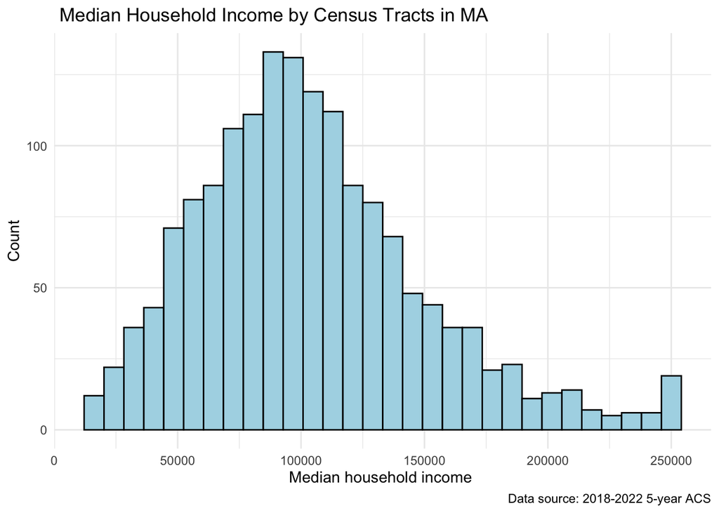

```r
df2_wide2 %>%  ggplot(aes(median_income)) +
   geom_histogram(fill = "lightblue", colour = "black") +
  labs(title = " Median Household Income by Census Tracts in MA",
       caption = "Data source: 2018-2022 5-year ACS", x = "Median household income ", y = "Count") + theme_minimal()
```

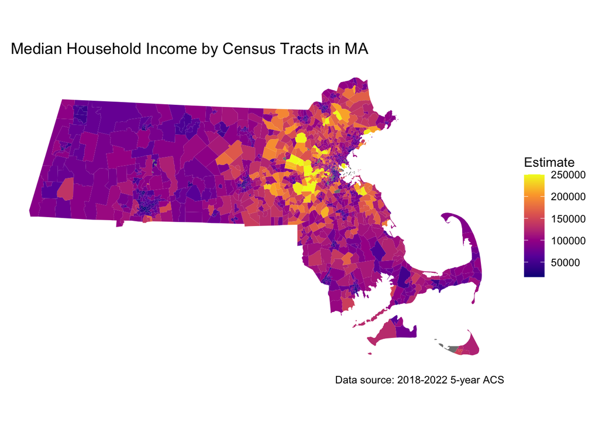

```r
df2_wide1<-df2_wide1 %>% rename(median_income = "B19013_001E")
df2_wide1 %>% ggplot(aes(fill = median_income)) +
  geom_sf(color = NA) +
  coord_sf(crs = 6491, datum = NA) +
  scale_fill_viridis_c(option = "C",direction = 1) +
  labs(title = " Median Household Income by Census Tracts in MA",
       caption = "Data source: 2018-2022 5-year ACS",
       fill = "Estimate") + theme_minimal()
```

```r
#6491   NAD83(2011) / Massachusetts Mainland Zone meters
# coord_sf(crs = 6491):  Help with projection/CRS
# coords_sf(datum = NA):  Remove gridlines, i.e graticules

##Colors
#https://colorbrewer2.org/#type=sequential&scheme=YlOrRd&n=3
#https://ggplot2.tidyverse.org/reference/scale_viridis.html
```

```r
racedat<-racedat %>% mutate(Percentage = 100 * (estimate / summary_est))
head(racedat)
```

```
## Simple feature collection with 6 features and 8 fields
## Geometry type: MULTIPOLYGON
## Dimension:     XY
## Bounding box:  xmin: -71.12725 ymin: 42.39667 xmax: -71.11696 ymax: 42.40329
## Geodetic CRS:  NAD83
##         GEOID                                               NAME
## 1 25017350500 Census Tract 3505, Middlesex County, Massachusetts
## 2 25017350500 Census Tract 3505, Middlesex County, Massachusetts
## 3 25017350500 Census Tract 3505, Middlesex County, Massachusetts
## 4 25017350500 Census Tract 3505, Middlesex County, Massachusetts
## 5 25017350500 Census Tract 3505, Middlesex County, Massachusetts
## 6 25017350500 Census Tract 3505, Middlesex County, Massachusetts
##             variable estimate moe summary_est summary_moe
## 1 Non-Hispanic White     1408 143        1593         145
## 2 Non-Hispanic Black       18  19        1593         145
## 3  Non-Hispanic AIAN        0  12        1593         145
## 4 Non-Hispanic Asian       58  56        1593         145
## 5  Non-Hispanic NHPI        0  12        1593         145
## 6    Hispanic/Latino       86  50        1593         145
##                         geometry Percentage
## 1 MULTIPOLYGON (((-71.12725 4...  88.386692
## 2 MULTIPOLYGON (((-71.12725 4...   1.129944
## 3 MULTIPOLYGON (((-71.12725 4...   0.000000
## 4 MULTIPOLYGON (((-71.12725 4...   3.640929
## 5 MULTIPOLYGON (((-71.12725 4...   0.000000
## 6 MULTIPOLYGON (((-71.12725 4...   5.398619
```

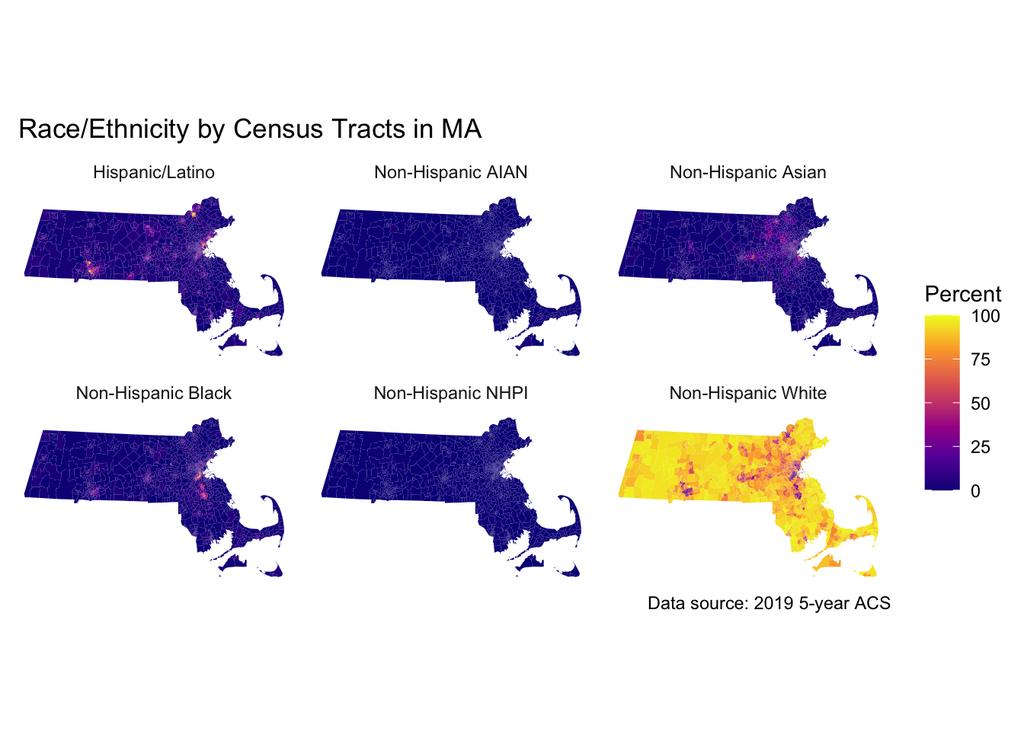

```r
racedat %>% ggplot(aes(fill = Percentage)) +
  facet_wrap(~ variable) +
  geom_sf(color = NA) +
  coord_sf(crs = 6491, datum = NA) +
  scale_fill_viridis_c(option = "C",direction = 1) +
  labs(title = " Race/Ethnicity by Census Tracts in MA",
       caption = "Data source: 2019 5-year ACS",
       fill = "Percent") + theme_minimal()
```

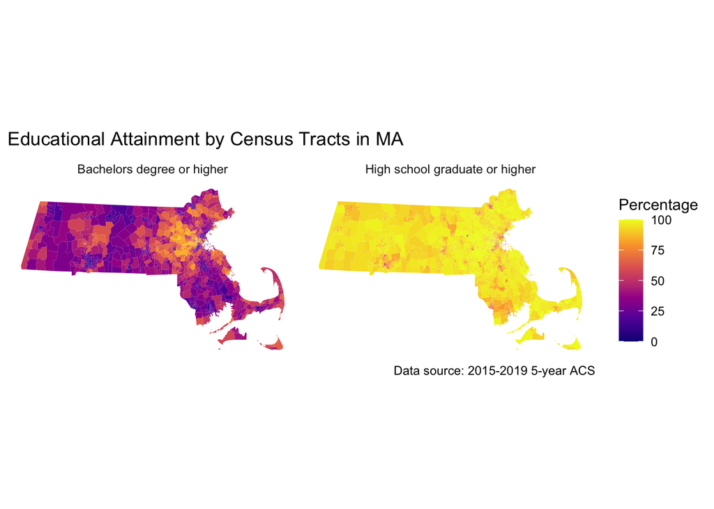

```r
#Other demographic variables
vars<-c(`High school graduate or higher` = "DP02_0067P",
                 `Bachelors degree or higher` = "DP02_0068P",
                 `Below Poverty Line` = "DP03_0119P",
                  `Renter Occupied Housing` = "DP04_0047P",
                   `Owner Occupied Housing` = "DP04_0046P")


demographics_2019<-get_acs(state = "MA", geography = "tract",
                  variables = vars, year = 2019, geometry = TRUE)

demographics_2019 %>% filter(variable %in% c("High school graduate or higher","Bachelors degree or higher")) %>% ggplot(aes(fill = estimate)) +
  facet_wrap(~ variable) +
  geom_sf(color = NA) +
  coord_sf(crs = 6491, datum = NA) +
  scale_fill_viridis_c(option = "C",direction = 1) +
  labs(title = "Educational Attainment by Census Tracts in MA",
       caption = "Data source: 2015-2019 5-year ACS",
       fill = "Percentage") + theme_minimal()
```

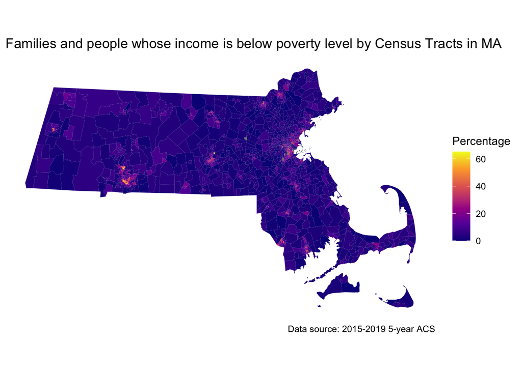

```r
demographics_2019 %>% filter(variable==c("Below Poverty Line")) %>% ggplot(aes(fill = estimate)) +
  geom_sf(color = NA) +
  coord_sf(crs = 6491, datum = NA) +
  scale_fill_viridis_c(option = "C",direction = 1) +
  labs(title = "Families and people whose income is below poverty level by Census Tracts in MA",
       caption = "Data source: 2015-2019 5-year ACS",
       fill = "Percentage") + theme_minimal()
```

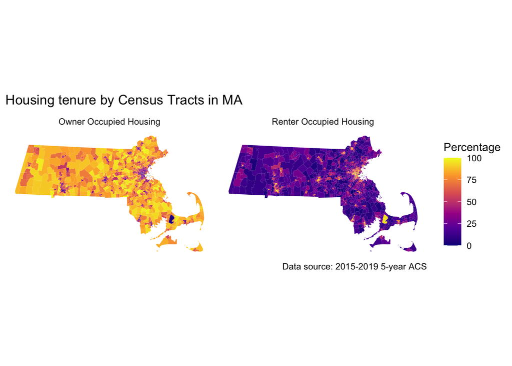

```r
demographics_2019 %>% filter(variable %in% c("Renter Occupied Housing","Owner Occupied Housing")) %>%
  ggplot(aes(fill = estimate)) +
  facet_wrap(~ variable) +
  geom_sf(color = NA) +
  coord_sf(crs = 6491, datum = NA) +
  scale_fill_viridis_c(option = "C",direction = 1) +
  labs(title = "Housing tenure by Census Tracts in MA",
       caption = "Data source: 2015-2019 5-year ACS",
       fill = "Percentage") + theme_minimal()
```

## Limitations of using these data

- Aggregate (percentages, median values, ratios, counts) at geographical levels, and household level (ACS, e.g., “total population” is really “total population in households.)
- Data are zero-inflated (some data might be suppressed due to small units like census tracts)
- Missing data due to household non-response or data suppression.
- Data are essentially point estimates for year intervals (e.g., 5-year estimates from ACS), and ACS provides marginal error estimates.
- Ecological studies